# Swire_EDA_Georgia

Georgia Christodoulou

2025-02-04

```r
knitr::opts_chunk$set(warning = FALSE, message = FALSE)
```

# Business Problem

Regional beverage bottler Swire Coca-Cola (SCCU) relies on two distribution models: 1) “Red Truck”, which features high-volume customers serviced personally by Swire, and 2) “White Truck” or “Alternate Route to Market”, which entails smaller customers serviced by a third-party distributor.

Swire’s current segmenting strategy has led to misallocation of resources, inflated expenses, and missed opportunities from clients with high-growth potential. Swire aims to better algin their customers with the business proposition of these models by identifying customer characteristics and ordering behavior that better determines the right business model for the long-term relationship.

# Questions

What are the most common order types, cold drink channels, trade channels, etc.? Is there an obvious trend between increasing customer count and ordered gallons in a primary customer group? Are there any trade channels that could suggest high growth potential but aren’t as obvious?

# Libraries and Data Import

```r
library(tidyverse)
library(dbplyr)
library(data.table)
library(janitor)
library(psych)

transactions <- as.data.frame(fread("data/transactional_data.csv"))
customer_address <- as.data.frame(fread("data/customer_address_and_zip_mapping.csv"))
customer_profile <- as.data.frame(fread("data/customer_profile.csv"))
delivery_cost <- readxl::read_xlsx('data/delivery_cost_data.xlsx')
```

# Cost Data Preparation

```r
# separate volume range into mix and max
delivery_cost <- delivery_cost %>%
  separate("Vol Range", into = c("min_vol", "max_vol"), sep = "-", convert = TRUE) %>%
  mutate(
    max_vol = ifelse(str_detect(min_vol, "\\+"), Inf, as.numeric(max_vol)),
    min_vol = as.numeric(str_replace(min_vol, "\\+", ""))
  )
```

# Customer Address Preparation

```r
# separate full customer address
customer_address <- customer_address %>%
  separate(full_address, into = c("zip", "city", "state", "state_abbr", "county", "region", "lat", "lon"), sep = ",", convert = TRUE)
```

# Join Data

```r
# join transactions an customer profile
joined_data <- left_join(transactions, customer_profile, by = "CUSTOMER_NUMBER")

# get annual volume by customer
annual_customer_vol <- joined_data %>%
  group_by(CUSTOMER_NUMBER, YEAR, COLD_DRINK_CHANNEL) %>%
  summarize(annual_gallons = sum(ORDERED_GALLONS),
            annual_cases = sum(ORDERED_CASES))

# assign median cost to customer
# cases
annual_customer_case_cost <-
  left_join(annual_customer_vol, delivery_cost, by = c("COLD_DRINK_CHANNEL" = "Cold Drink Channel")) %>%
  filter(annual_cases >= min_vol & annual_cases <= max_vol,
    `Applicable To` == "Bottles and Cans",
    `Cost Type` == "Per Case") %>%
  select(CUSTOMER_NUMBER, YEAR, COLD_DRINK_CHANNEL, annual_cases, median_delivery_cost_cases = `Median Delivery Cost`)

# gallons
annual_customer_gallon_cost <-
  left_join(annual_customer_vol, delivery_cost, by = c("COLD_DRINK_CHANNEL" = "Cold Drink Channel")) %>%
  filter(annual_gallons >= min_vol & annual_gallons <= max_vol,
    `Applicable To` == "Fountain",
    `Cost Type` == "Per Gallon") %>%
  select(CUSTOMER_NUMBER, YEAR, COLD_DRINK_CHANNEL, annual_gallons, median_delivery_cost_gallons = `Median Delivery Cost`)

# join customer vol to costs tables
annual_customer_costs <-
  left_join(annual_customer_vol, annual_customer_case_cost, by = c("CUSTOMER_NUMBER", "YEAR", "COLD_DRINK_CHANNEL", "annual_cases"))
annual_customer_costs <-
  left_join(annual_customer_costs, annual_customer_gallon_cost, by = c("CUSTOMER_NUMBER", "YEAR", "COLD_DRINK_CHANNEL", "annual_gallons"))

# join median delivery costs to transaction data
joined_data_with_cost <-
  left_join(joined_data, annual_customer_costs, by = c("CUSTOMER_NUMBER", "YEAR", "COLD_DRINK_CHANNEL"))

joined_data <- left_join(joined_data, customer_address, by = c("ZIP_CODE" = "zip"))

# join transactions, customer profiles, and delivery cost with customer address
joined_data_with_cost <- left_join(joined_data_with_cost, customer_address, by = c("ZIP_CODE" = "zip"))
```

# Variable Cleaning

```r
# date types
joined_data_with_cost <- joined_data_with_cost %>%
  mutate(
    FIRST_DELIVERY_DATE = ymd(mdy(FIRST_DELIVERY_DATE)),
    ON_BOARDING_DATE = ymd(mdy(ON_BOARDING_DATE)),
    TRANSACTION_DATE = ymd(mdy(TRANSACTION_DATE)))

# IDs as strings
joined_data_with_cost <- joined_data_with_cost %>%
  mutate(
    PRIMARY_GROUP_NUMBER = as.character(PRIMARY_GROUP_NUMBER),
    ZIP_CODE = as.character(ZIP_CODE),
    CUSTOMER_NUMBER = as.character(CUSTOMER_NUMBER)
  )

# factors
joined_data_with_cost <- joined_data_with_cost %>%
  mutate(
    COLD_DRINK_CHANNEL = as.factor(COLD_DRINK_CHANNEL),
    FREQUENT_ORDER_TYPE = as.factor(FREQUENT_ORDER_TYPE),
    TRADE_CHANNEL = as.factor(TRADE_CHANNEL),
    SUB_TRADE_CHANNEL = as.factor(SUB_TRADE_CHANNEL),
    ORDER_TYPE = as.factor(ORDER_TYPE)
  )

# variable name standardization
joined_data_with_cost <- joined_data_with_cost %>% clean_names()

joined_data_with_cost %>% str()
```

```
## 'data.frame':    1045540 obs. of  32 variables:
##  $ transaction_date            : Date, format: "2023-01-05" "2023-01-06" ...
##  $ week                        : int  1 1 2 2 3 4 4 4 4 5 ...
##  $ year                        : int  2023 2023 2023 2023 2023 2023 2023 2023 2023 2023 ...
##  $ customer_number             : chr  "501202893" "500264574" "501174701" "600586532" ...
##  $ order_type                  : Factor w/ 7 levels "CALL CENTER",..: 3 3 3 7 7 1 3 1 1 3 ...
##  $ ordered_cases               : num  1 12.5 2 18 29 1.5 6 0 4 18 ...
##  $ loaded_cases                : num  1 12.5 2 16 29 1.5 5 0 1 17 ...
##  $ delivered_cases             : num  1 12.5 2 16 29 1.5 5 0 1 17 ...
##  $ ordered_gallons             : num  90 0 0 2.5 0 0 0 25 0 0 ...
##  $ loaded_gallons              : num  90 0 0 2.5 0 0 0 25 0 0 ...
##  $ delivered_gallons           : num  90 0 0 2.5 0 0 0 25 0 0 ...
##  $ primary_group_number        : chr  NA "1894" NA "8397" ...
##  $ frequent_order_type         : Factor w/ 6 levels "CALL CENTER",..: 6 5 4 6 6 6 6 5 6 6 ...
##  $ first_delivery_date         : Date, format: "2021-05-07" "2018-03-23" ...
```

[output cut: 18 more lines]

# New Columns

```r
# number of annual returns
neg_deliveries <- joined_data_with_cost %>%
  filter(delivered_cases < 0 | delivered_gallons < 0) %>%
  group_by(customer_number, year) %>%
  summarize(neg_deliveries = n())

# number of customers per primary customer group
customers_by_group <- joined_data_with_cost %>%
  group_by(primary_group_number, year) %>%
  summarize(num_customers = n())

# join returns with rest of data
joined_data_with_cost <-
  left_join(joined_data_with_cost, neg_deliveries, by = c("customer_number", "year"))

# join number of customers with the rest of the data
joined_data_with_cost <-
  left_join(joined_data_with_cost, customers_by_group, by = c("primary_group_number", "year"))

# replace NAs with 0
joined_data_with_cost <- joined_data_with_cost %>%
  mutate(across(c(median_delivery_cost_cases, median_delivery_cost_gallons, neg_deliveries), ~ replace_na(., 0)))

joined_data_with_cost %>% str()
```

```
## 'data.frame':    1045540 obs. of  34 variables:
##  $ transaction_date            : Date, format: "2023-01-05" "2023-01-06" ...
##  $ week                        : int  1 1 2 2 3 4 4 4 4 5 ...
##  $ year                        : int  2023 2023 2023 2023 2023 2023 2023 2023 2023 2023 ...
##  $ customer_number             : chr  "501202893" "500264574" "501174701" "600586532" ...
##  $ order_type                  : Factor w/ 7 levels "CALL CENTER",..: 3 3 3 7 7 1 3 1 1 3 ...
##  $ ordered_cases               : num  1 12.5 2 18 29 1.5 6 0 4 18 ...
##  $ loaded_cases                : num  1 12.5 2 16 29 1.5 5 0 1 17 ...
##  $ delivered_cases             : num  1 12.5 2 16 29 1.5 5 0 1 17 ...
##  $ ordered_gallons             : num  90 0 0 2.5 0 0 0 25 0 0 ...
##  $ loaded_gallons              : num  90 0 0 2.5 0 0 0 25 0 0 ...
##  $ delivered_gallons           : num  90 0 0 2.5 0 0 0 25 0 0 ...
##  $ primary_group_number        : chr  NA "1894" NA "8397" ...
##  $ frequent_order_type         : Factor w/ 6 levels "CALL CENTER",..: 6 5 4 6 6 6 6 5 6 6 ...
##  $ first_delivery_date         : Date, format: "2021-05-07" "2018-03-23" ...
```

[output cut: 20 more lines]

```r
joined_data_with_cost %>% summary()
```

```
##  transaction_date          week            year      customer_number
##  Min.   :2023-01-01   Min.   : 1.00   Min.   :2023   Length:1045540
##  1st Qu.:2023-06-30   1st Qu.:14.00   1st Qu.:2023   Class :character
##  Median :2023-12-27   Median :26.00   Median :2023   Mode  :character
##  Mean   :2023-12-27   Mean   :26.23   Mean   :2023
##  3rd Qu.:2024-06-25   3rd Qu.:38.00   3rd Qu.:2024
##  Max.   :2024-12-31   Max.   :52.00   Max.   :2024
##
##          order_type     ordered_cases      loaded_cases     delivered_cases
##  CALL CENTER  :297542   Min.   :   0.00   Min.   :   0.00   Min.   :-3132.00
##  EDI          : 47683   1st Qu.:   0.00   1st Qu.:   0.00   1st Qu.:    0.00
##  MYCOKE LEGACY:329597   Median :   7.00   Median :   7.00   Median :    6.00
##  MYCOKE360    : 76010   Mean   :  26.85   Mean   :  25.92   Mean   :   25.13
##  null         : 11131   3rd Qu.:  18.50   3rd Qu.:  18.00   3rd Qu.:   17.33
##  OTHER        : 15222   Max.   :8479.89   Max.   :8171.56   Max.   : 8069.48
##  SALES REP    :268355
##  ordered_gallons    loaded_gallons     delivered_gallons   primary_group_number
##  Min.   :   0.000   Min.   :   0.000   Min.   :-1792.500   Length:1045540
##  1st Qu.:   0.000   1st Qu.:   0.000   1st Qu.:    0.000   Class :character
##  Median :   0.000   Median :   0.000   Median :    0.000   Mode  :character
##  Mean   :   9.874   Mean   :   9.605   Mean   :    9.208
##  3rd Qu.:  12.500   3rd Qu.:  12.500   3rd Qu.:   12.500
##  Max.   :2562.500   Max.   :2562.500   Max.   : 2292.500
##
##     frequent_order_type first_delivery_date  on_boarding_date
##  CALL CENTER  : 26420   Min.   :2015-11-28   Min.   :1981-08-01
##  EDI          : 11516   1st Qu.:2017-05-02   1st Qu.:2010-03-02
##  MYCOKE LEGACY: 24523   Median :2018-05-03   Median :2017-01-05
##  MYCOKE360    : 46780   Mean   :2019-03-31   Mean   :2014-04-06
##  OTHER        :187002   3rd Qu.:2021-04-16   3rd Qu.:2021-02-09
##  SALES REP    :749299   Max.   :2024-12-31   Max.   :2024-12-23
##
##      cold_drink_channel                 trade_channel
##  DINING       :527910   FAST CASUAL DINING     :247262
##  GOODS        :173384   COMPREHENSIVE DINING   :164577
##  EVENT        : 96258   GENERAL RETAILER       :106288
##  BULK TRADE   : 87527   GENERAL                : 73929
##  PUBLIC SECTOR: 53937   OTHER DINING & BEVERAGE: 70562
##  ACCOMMODATION: 44330   OUTDOOR ACTIVITIES     : 57713
##  (Other)      : 62194   (Other)                :325209
```

[output cut: 25 more lines]

```
##  Length:1045540     Length:1045540     Length:1045540     Min.   :  1.00
##  Class :character   Class :character   Class :character   1st Qu.: 15.00
##  Mode  :character   Mode  :character   Mode  :character   Median : 27.00
##                                                           Mean   : 62.38
##                                                           3rd Qu.:115.00
##                                                           Max.   :209.00
##
##       lat             lon          neg_deliveries   num_customers
##  Min.   :30.36   Min.   :-102.00   Min.   :0.0000   Min.   :     1
##  1st Qu.:37.97   1st Qu.: -91.40   1st Qu.:0.0000   1st Qu.:   881
##  Median :39.35   Median : -77.54   Median :0.0000   Median : 25112
##  Mean   :39.72   Mean   : -82.11   Mean   :0.1179   Mean   :117478
##  3rd Qu.:42.15   3rd Qu.: -71.84   3rd Qu.:0.0000   3rd Qu.:244985
##  Max.   :42.86   Max.   : -69.96   Max.   :7.0000   Max.   :245910
##
```

# All Customers

## Gallons by Customer

```r
# total gallons ordered by customer by year
joined_data_with_cost %>%
  group_by(customer_number, year) %>%
  summarize(gallons = sum(ordered_gallons + ordered_cases)) %>%
  arrange(desc(customer_number))
```

```
## # A tibble: 55,653 × 3
## # Groups:   customer_number [30,322]
##    customer_number  year gallons
##    <chr>           <int>   <dbl>
##  1 600975408        2023    67
##  2 600975408        2024    98
##  3 600975383        2023    54
##  4 600975383        2024    61
##  5 600975377        2023   141
##  6 600975377        2024   178.
##  7 600975334        2023   530
##  8 600975334        2024   500
##  9 600975319        2023    91.2
## 10 600975319        2024   105
## # ℹ 55,643 more rows
```

```r
# transaction frequency by customer
joined_data_with_cost %>%
  group_by(customer_number, year) %>%
  summarize(gallons = round(sum(ordered_gallons + ordered_cases),2), transactions = n_distinct(transaction_date),
            gal_per_transaction = round((sum(ordered_gallons + ordered_cases))/ n_distinct(transaction_date),2)) %>%
  pivot_wider(names_from = year, values_from = c(gallons, transactions, gal_per_transaction), names_sep = "_") %>%
  arrange(desc(gal_per_transaction_2024))
```

```
## # A tibble: 30,322 × 7
## # Groups:   customer_number [30,322]
##    customer_number gallons_2023 gallons_2024 transactions_2023 transactions_2024
##    <chr>                  <dbl>        <dbl>             <int>             <int>
##  1 501267499            376539.      459176.               118               126
##  2 600064039            160752       188486.                59                57
##  3 600573998            376588       402665                160               160
##  4 501725579                NA        19008                 NA                 8
##  5 600261951            106644       127146                 55                54
##  6 600055359             89104.       99150                 57                58
##  7 600265975            207290.      264725                153               159
##  8 600252509            204121        71291                 98                44
##  9 600056098              1306         1603                  2                 1
## 10 500733119            139520       168622                 99               110
## # ℹ 30,312 more rows
## # ℹ 2 more variables: gal_per_transaction_2023 <dbl>,
## #   gal_per_transaction_2024 <dbl>
```

## Customer YoY Changes

```r
# year over year changes in gallon volume by customer
joined_data_with_cost %>%
  group_by(customer_number, year, first_delivery_date, trade_channel, sub_trade_channel) %>%
  summarize(gallons = sum(ordered_gallons + ordered_cases)) %>%
  pivot_wider(names_from = year, values_from = gallons) %>%
  mutate(Unit_Delta = (`2024` - `2023`)) %>%
  arrange(desc(Unit_Delta))
```

```
## # A tibble: 30,322 × 7
## # Groups:   customer_number, first_delivery_date, trade_channel [30,322]
##    customer_number first_delivery_date trade_channel sub_trade_channel    `2023`
##    <chr>           <date>              <fct>         <fct>                 <dbl>
##  1 501267499       2021-10-26          TRAVEL        CRUISE               3.77e5
##  2 600265975       2016-08-01          GENERAL       COMPREHENSIVE PROVI… 2.07e5
##  3 500733119       2018-08-30          TRAVEL        CRUISE               1.40e5
##  4 600064039       2018-05-03          TRAVEL        CRUISE               1.61e5
##  5 600573998       2017-02-28          TRAVEL        CRUISE               3.77e5
##  6 500405618       2018-05-03          BULK TRADE    BULK TRADE           5.88e2
##  7 501031108       2019-12-23          SUPERSTORE    ONLINE STORE         3.89e4
##  8 600261951       2016-08-05          TRAVEL        CRUISE               1.07e5
##  9 501530720       2023-07-31          RECREATION    RECREATION ARENA     1.26e4
## 10 600585734       2017-03-01          TRAVEL        CRUISE               8.48e4
## # ℹ 30,312 more rows
## # ℹ 2 more variables: `2024` <dbl>, Unit_Delta <dbl>
```

## Primary Customer Group

```r
# year over year changes in gallon volume by primary customer group
primary_group_gallon_comp <- joined_data_with_cost %>%
  filter(!is.na(primary_group_number)) %>%
  group_by(primary_group_number, year) %>%
  summarize(
    gallons = round(sum(ordered_gallons + ordered_cases, na.rm = TRUE),2),
    cust_cnt = n_distinct(customer_number),
    .groups = "drop"
  ) %>%
  pivot_wider(names_from = year, values_from = c(gallons, cust_cnt), names_sep = "_") %>%
  mutate(
    gallon_delta = round(gallons_2024 - gallons_2023, 2),
    cust_delta = cust_cnt_2024 - cust_cnt_2023
  ) %>%
  arrange(desc(gallon_delta))

primary_group_gallon_comp
```

```
## # A tibble: 1,020 × 7
##    primary_group_number gallons_2023 gallons_2024 cust_cnt_2023 cust_cnt_2024
##    <chr>                       <dbl>        <dbl>         <int>         <int>
##  1 408                        22426.      513149.             1            14
##  2 481                       435413.      520446.             7             7
##  3 7365                      246430.      298382.             6             5
##  4 464                       267611       317953.             3             9
##  5 5566                       27991.       72013.           139           139
##  6 330                       477451       519197.             4             6
##  7 7353                      380368.      415225.            14            14
##  8 8407                      548962.      581740.            13            13
##  9 374                       274238       305207              6             6
## 10 7103                       20106.       48896.             3             4
## # ℹ 1,010 more rows
## # ℹ 2 more variables: gallon_delta <dbl>, cust_delta <int>
```

## Order Type

```r
# gallons by order type and year for all customers
joined_data_with_cost %>%
  group_by(order_type, year) %>%
  summarize(gallons = sum(ordered_gallons + ordered_cases))
```

```
## # A tibble: 13 × 3
## # Groups:   order_type [7]
##    order_type     year  gallons
##    <fct>         <int>    <dbl>
##  1 CALL CENTER    2023 3752829.
##  2 CALL CENTER    2024 3385433.
##  3 EDI            2023 1788635.
##  4 EDI            2024 2368466.
##  5 MYCOKE LEGACY  2023 6619552.
##  6 MYCOKE LEGACY  2024 4262363.
##  7 MYCOKE360      2024 2884780.
##  8 null           2023  144833.
##  9 null           2024  149128.
## 10 OTHER          2023 1336559.
## 11 OTHER          2024 1097215.
## 12 SALES REP      2023 5063524.
## 13 SALES REP      2024 5544488.
```

```r
# number of customers by order type and year for all customers
joined_data_with_cost %>%
  group_by(order_type, year) %>%
  summarize(customer_count = n_distinct(customer_number))
```

```
## # A tibble: 13 × 3
## # Groups:   order_type [7]
##    order_type     year customer_count
##    <fct>         <int>          <int>
##  1 CALL CENTER    2023          12818
##  2 CALL CENTER    2024          13310
##  3 EDI            2023            847
##  4 EDI            2024            903
##  5 MYCOKE LEGACY  2023          10907
##  6 MYCOKE LEGACY  2024          11686
##  7 MYCOKE360      2024          10152
##  8 null           2023           2304
##  9 null           2024           2209
## 10 OTHER          2023           3337
## 11 OTHER          2024           2395
## 12 SALES REP      2023           9155
## 13 SALES REP      2024          12034
```

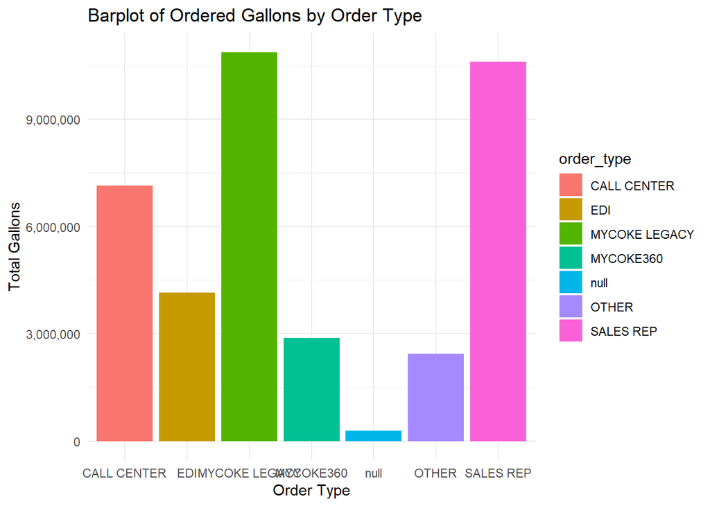

```r
# for all customers
joined_data_with_cost %>%
  group_by(order_type) %>%
  summarize(gallons = sum(ordered_gallons + ordered_cases)) %>%
  ggplot(aes(x = order_type, y = gallons, fill = order_type)) +
  geom_bar(stat="identity") +
  ggtitle("Barplot of Ordered Gallons by Order Type") +
  labs(x = "Order Type", y = "Total Gallons") +
  scale_y_continuous(labels = scales::comma) +
  theme_minimal()
```

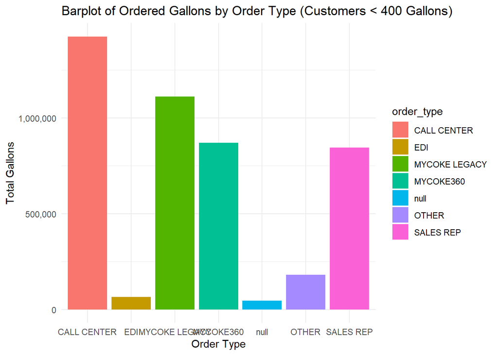

```r
# for customers with < 400 gallons per year
joined_data_with_cost %>%
  group_by(customer_number, order_type) %>%
  summarize(total_gallons = sum(ordered_gallons + ordered_cases, na.rm = TRUE)) %>%
  filter(total_gallons < 400) %>%
  group_by(order_type) %>%
  summarize(gallons = sum(total_gallons)) %>%
  ggplot(aes(x = order_type, y = gallons, fill = order_type)) +
  geom_bar(stat = "identity") +
  ggtitle("Barplot of Ordered Gallons by Order Type (Customers < 400 Gallons)") +
  labs(x = "Order Type", y = "Total Gallons") +
  scale_y_continuous(labels = scales::comma) +
  theme_minimal()
```

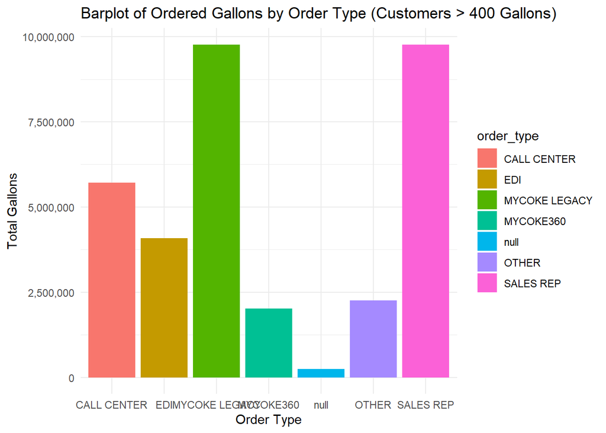

```r
# for customers with > 400 gallons per year
joined_data_with_cost %>%
  group_by(customer_number, order_type) %>%
  summarize(total_gallons = sum(ordered_gallons + ordered_cases, na.rm = TRUE)) %>%
  filter(total_gallons > 400) %>%
  group_by(order_type) %>%
  summarize(gallons = sum(total_gallons)) %>%
  ggplot(aes(x = order_type, y = gallons, fill = order_type)) +
  geom_bar(stat = "identity") +
  ggtitle("Barplot of Ordered Gallons by Order Type (Customers > 400 Gallons)") +
  labs(x = "Order Type", y = "Total Gallons") +
  scale_y_continuous(labels = scales::comma) +
  theme_minimal()
```

## Frequent Order Type

```r
# gallons by frequent order type and year for all customers
joined_data_with_cost %>%
  group_by(frequent_order_type, year) %>%
  summarize(gallons = sum(ordered_gallons + ordered_cases))
```

```
## # A tibble: 12 × 3
## # Groups:   frequent_order_type [6]
##    frequent_order_type  year   gallons
##    <fct>               <int>     <dbl>
##  1 CALL CENTER          2023   179514
##  2 CALL CENTER          2024   186632.
##  3 EDI                  2023   149081.
##  4 EDI                  2024   305438.
##  5 MYCOKE LEGACY        2023   246565.
##  6 MYCOKE LEGACY        2024   244421.
##  7 MYCOKE360            2023   381317.
##  8 MYCOKE360            2024   581339.
##  9 OTHER                2023  3753564.
## 10 OTHER                2024  3612093.
## 11 SALES REP            2023 13995891.
## 12 SALES REP            2024 14761952.
```

```r
# number of customers by frequent order type and year for all customers
joined_data_with_cost %>%
  group_by(frequent_order_type, year) %>%
  summarize(customer_count = n_distinct(customer_number))
```

```
## # A tibble: 12 × 3
## # Groups:   frequent_order_type [6]
##    frequent_order_type  year customer_count
##    <fct>               <int>          <int>
##  1 CALL CENTER          2023           1143
##  2 CALL CENTER          2024           1299
##  3 EDI                  2023            327
##  4 EDI                  2024            341
##  5 MYCOKE LEGACY        2023            770
##  6 MYCOKE LEGACY        2024            905
##  7 MYCOKE360            2023           1543
##  8 MYCOKE360            2024           2384
##  9 OTHER                2023           5063
## 10 OTHER                2024           5158
## 11 SALES REP            2023          17206
## 12 SALES REP            2024          19514
```

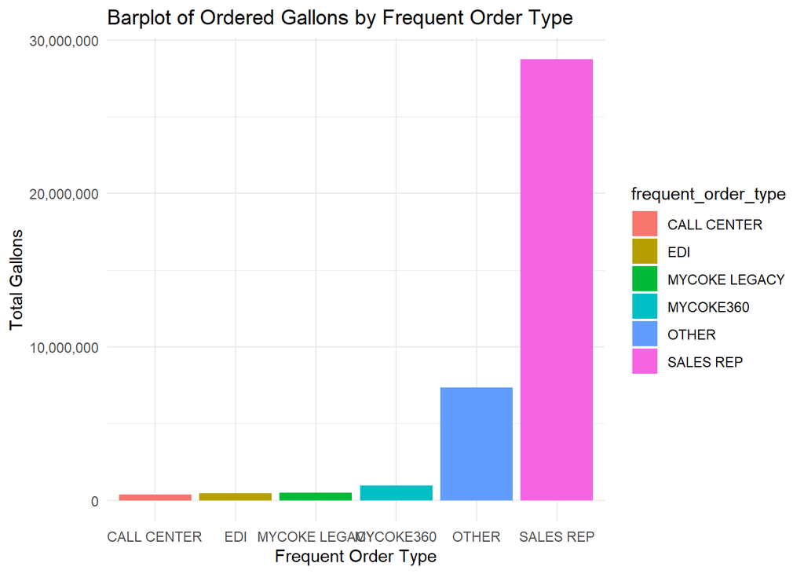

```r
# for all customers
joined_data_with_cost %>%
  group_by(frequent_order_type) %>%
  summarize(gallons = sum(ordered_gallons + ordered_cases)) %>%
  ggplot(aes(x = frequent_order_type, y = gallons, fill = frequent_order_type)) +
  geom_bar(stat="identity") +
  ggtitle("Barplot of Ordered Gallons by Frequent Order Type") +
  labs(x = "Frequent Order Type", y = "Total Gallons") +
  scale_y_continuous(labels = scales::comma) +
  theme_minimal()
```

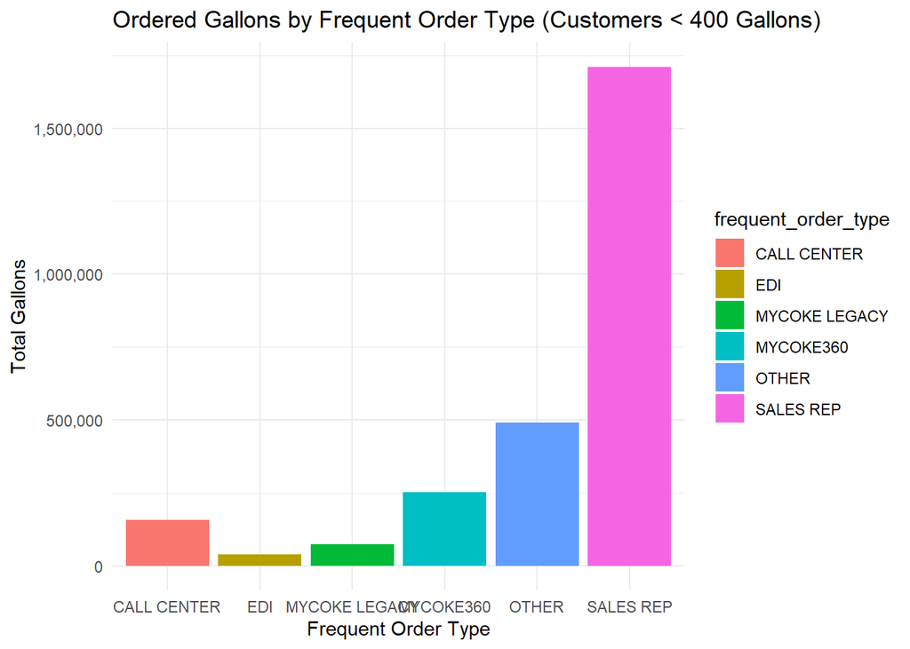

```r
# for customers with < 400 gallons per year
joined_data_with_cost %>%
  group_by(customer_number, frequent_order_type) %>%
  summarize(total_gallons = sum(ordered_gallons + ordered_cases, na.rm = TRUE)) %>%
  filter(total_gallons < 400) %>%
  group_by(frequent_order_type) %>%
  summarize(gallons = sum(total_gallons)) %>%
  ggplot(aes(x = frequent_order_type, y = gallons, fill = frequent_order_type)) +
  geom_bar(stat = "identity") +
  ggtitle("Ordered Gallons by Frequent Order Type (Customers < 400 Gallons)") +
  labs(x = "Frequent Order Type", y = "Total Gallons") +
  scale_y_continuous(labels = scales::comma) +
  theme_minimal()
```

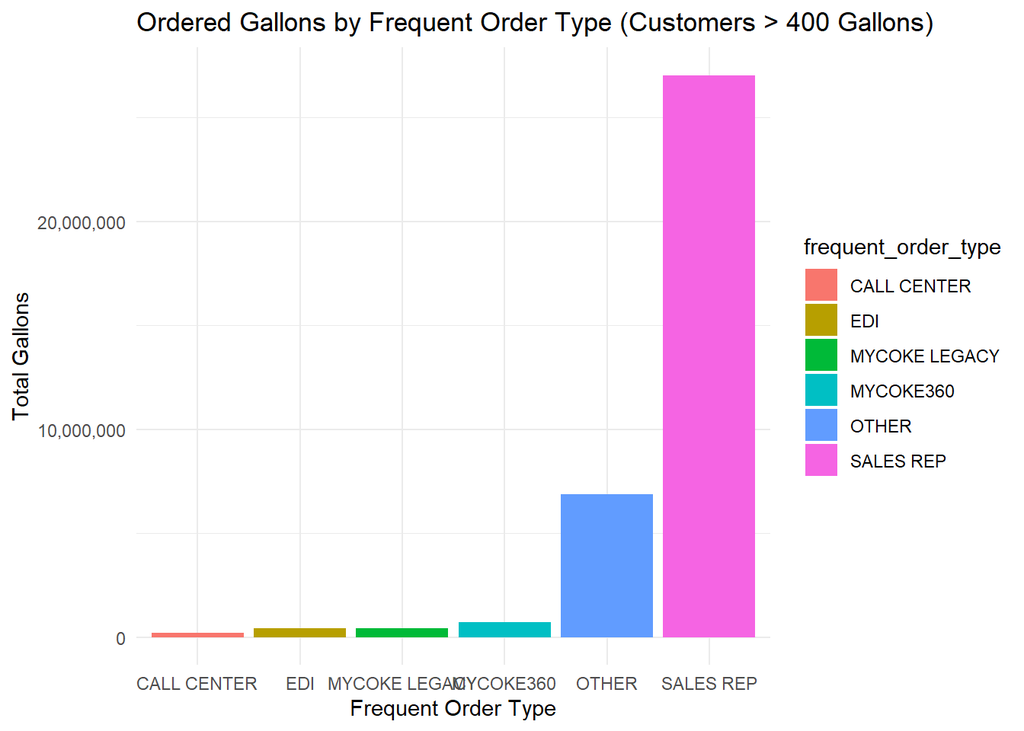

```r
# for customers with > 400 gallons per year
joined_data_with_cost %>%
  group_by(customer_number, frequent_order_type) %>%
  summarize(total_gallons = sum(ordered_gallons + ordered_cases, na.rm = TRUE)) %>%
  filter(total_gallons > 400) %>%
  group_by(frequent_order_type) %>%
  summarize(gallons = sum(total_gallons)) %>%
  ggplot(aes(x = frequent_order_type, y = gallons, fill = frequent_order_type)) +
  geom_bar(stat = "identity") +
  ggtitle("Ordered Gallons by Frequent Order Type (Customers > 400 Gallons)") +
  labs(x = "Frequent Order Type", y = "Total Gallons") +
  scale_y_continuous(labels = scales::comma) +
  theme_minimal()
```

The most popular frequent order type for all customers is through a sales rep, however, customers with volume less than 400 gallons also use the call center and mycoke360/legacy more frequently that those with volume more than 400 gallons.

## Cold Drink Channel

```r
# gallons by cold drink channel and year for all customers
joined_data_with_cost %>%
  group_by(cold_drink_channel, year) %>%
  summarize(gallons = sum(ordered_gallons + ordered_cases))
```

```
## # A tibble: 18 × 3
## # Groups:   cold_drink_channel [9]
##    cold_drink_channel  year  gallons
##    <fct>              <int>    <dbl>
##  1 ACCOMMODATION       2023  476384.
##  2 ACCOMMODATION       2024  483019.
##  3 BULK TRADE          2023 4877747.
##  4 BULK TRADE          2024 5109930.
##  5 CONVENTIONAL        2023    5570.
##  6 CONVENTIONAL        2024    6052.
##  7 DINING              2023 5178051.
##  8 DINING              2024 5262748.
##  9 EVENT               2023 2377011.
## 10 EVENT               2024 2448306.
## 11 GOODS               2023 1705057.
## 12 GOODS               2024 2194385.
## 13 PUBLIC SECTOR       2023  999364.
## 14 PUBLIC SECTOR       2024 1027560.
## 15 WELLNESS            2023  622871.
## 16 WELLNESS            2024  609083.
## 17 WORKPLACE           2023 2463878.
## 18 WORKPLACE           2024 2550790.
```

```r
# customer count by cold drink channel and year for all customers
joined_data_with_cost %>%
  group_by(cold_drink_channel, year) %>%
  summarize(customer_count = n_distinct(customer_number))
```

```
## # A tibble: 18 × 3
## # Groups:   cold_drink_channel [9]
##    cold_drink_channel  year customer_count
##    <fct>              <int>          <int>
##  1 ACCOMMODATION       2023           1078
##  2 ACCOMMODATION       2024           1225
##  3 BULK TRADE          2023           1159
##  4 BULK TRADE          2024           1297
##  5 CONVENTIONAL        2023             47
##  6 CONVENTIONAL        2024             57
##  7 DINING              2023          12811
##  8 DINING              2024          15023
##  9 EVENT               2023           2614
## 10 EVENT               2024           2918
## 11 GOODS               2023           5357
## 12 GOODS               2024           5766
## 13 PUBLIC SECTOR       2023           1506
## 14 PUBLIC SECTOR       2024           1695
## 15 WELLNESS            2023            440
## 16 WELLNESS            2024            466
## 17 WORKPLACE           2023           1040
## 18 WORKPLACE           2024           1154
```

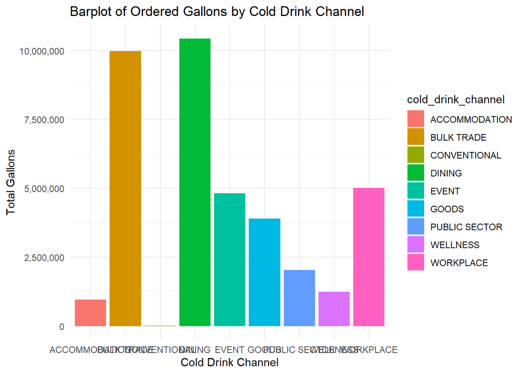

```r
# for all customers
joined_data_with_cost %>%
  group_by(cold_drink_channel) %>%
  summarize(gallons = sum(ordered_gallons + ordered_cases)) %>%
  ggplot(aes(x = cold_drink_channel, y = gallons, fill = cold_drink_channel)) +
  geom_bar(stat="identity") +
  ggtitle("Barplot of Ordered Gallons by Cold Drink Channel") +
  labs(x = "Cold Drink Channel", y = "Total Gallons") +
  scale_y_continuous(labels = scales::comma) +
  theme_minimal()
```

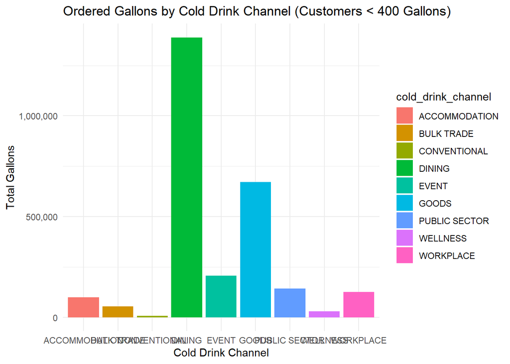

```r
# for customers with < 400 gallons per year
joined_data_with_cost %>%
  group_by(customer_number, cold_drink_channel) %>%
  summarize(total_gallons = sum(ordered_gallons + ordered_cases, na.rm = TRUE)) %>%
  filter(total_gallons < 400) %>%
  group_by(cold_drink_channel) %>%
  summarize(gallons = sum(total_gallons)) %>%
  ggplot(aes(x = cold_drink_channel, y = gallons, fill = cold_drink_channel)) +
  geom_bar(stat = "identity") +
  ggtitle("Ordered Gallons by Cold Drink Channel (Customers < 400 Gallons)") +
  labs(x = "Cold Drink Channel", y = "Total Gallons") +
  scale_y_continuous(labels = scales::comma) +
  theme_minimal()
```

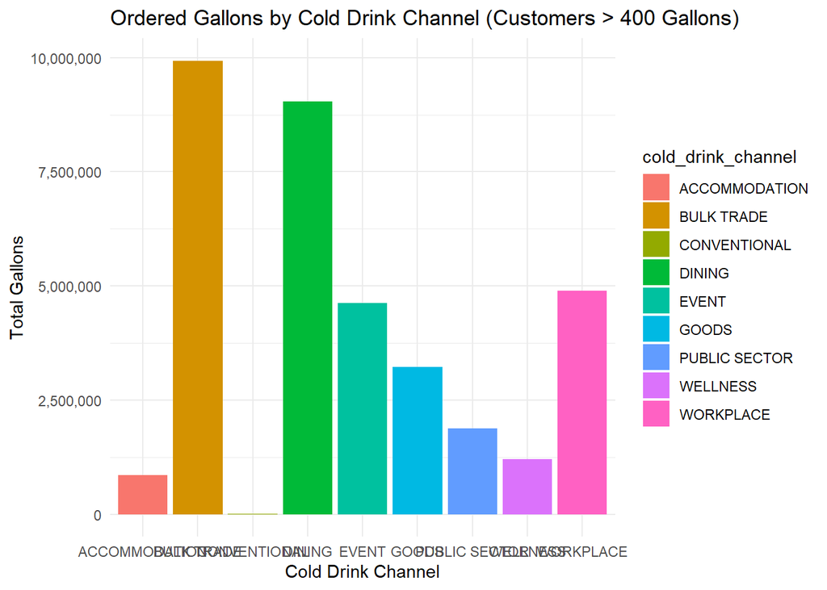

```r
# for customers with > 400 gallons per year
joined_data_with_cost %>%
  group_by(customer_number, cold_drink_channel) %>%
  summarize(total_gallons = sum(ordered_gallons + ordered_cases, na.rm = TRUE)) %>%
  filter(total_gallons > 400) %>%
  group_by(cold_drink_channel) %>%
  summarize(gallons = sum(total_gallons)) %>%
  ggplot(aes(x = cold_drink_channel, y = gallons, fill = cold_drink_channel)) +
  geom_bar(stat = "identity") +
  ggtitle("Ordered Gallons by Cold Drink Channel (Customers > 400 Gallons)") +
  labs(x = "Cold Drink Channel", y = "Total Gallons") +
  scale_y_continuous(labels = scales::comma) +
  theme_minimal()
```

Dining and goods are the main cold drink channels for customers with a volume of less than 400 gallons, while bulk trade and dining dominate for those with more than 400 gallons. This could suggest the need for a separate ‘dining’ cold drink channel analysis to compare characteristics between the two thresholds.

## Trade Channel

```r
# gallons by trade channel and year for all customers
joined_data_with_cost %>%
  group_by(trade_channel, year) %>%
  summarize(gallons = sum(ordered_gallons + ordered_cases))
```

```
## # A tibble: 51 × 3
## # Groups:   trade_channel [26]
##    trade_channel         year  gallons
##    <fct>                <int>    <dbl>
##  1 ACADEMIC INSTITUTION  2023  540210.
##  2 ACADEMIC INSTITUTION  2024  547376.
##  3 ACCOMMODATION         2023  476960.
##  4 ACCOMMODATION         2024  483683.
##  5 ACTIVITIES            2023  685544.
##  6 ACTIVITIES            2024  704640.
##  7 BULK TRADE            2023  749762.
##  8 BULK TRADE            2024  671594
##  9 COMPREHENSIVE DINING  2023 1558931.
## 10 COMPREHENSIVE DINING  2024 1567085.
## # ℹ 41 more rows
```

```r
# customers by trade channel and year for all customers
joined_data_with_cost %>%
  group_by(trade_channel, year) %>%
  summarize(customer_count = n_distinct(customer_number))
```

```
## # A tibble: 51 × 3
## # Groups:   trade_channel [26]
##    trade_channel         year customer_count
##    <fct>                <int>          <int>
##  1 ACADEMIC INSTITUTION  2023            353
##  2 ACADEMIC INSTITUTION  2024            407
##  3 ACCOMMODATION         2023           1080
##  4 ACCOMMODATION         2024           1227
##  5 ACTIVITIES            2023            256
##  6 ACTIVITIES            2024            297
##  7 BULK TRADE            2023             84
##  8 BULK TRADE            2024            103
##  9 COMPREHENSIVE DINING  2023           4246
## 10 COMPREHENSIVE DINING  2024           4581
## # ℹ 41 more rows
```

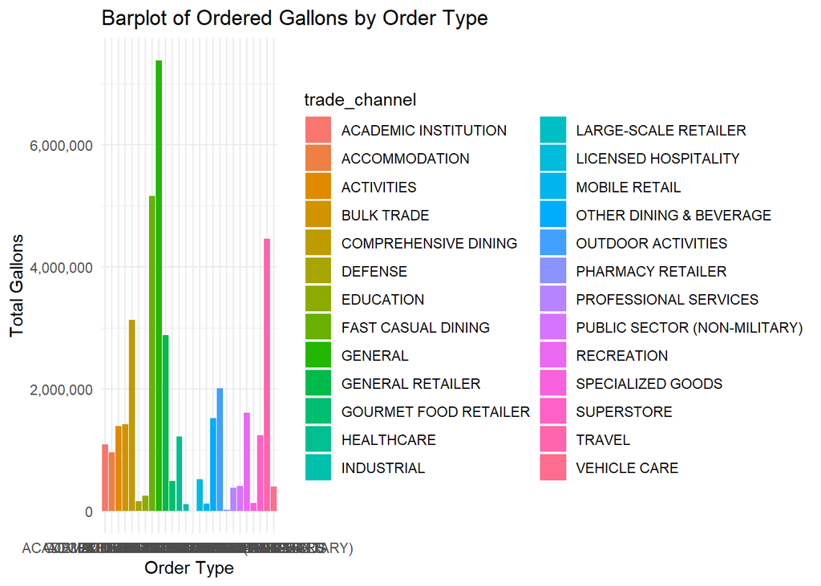

```r
# for all customers
joined_data_with_cost %>%
  group_by(trade_channel) %>%
  summarize(gallons = sum(ordered_gallons + ordered_cases)) %>%
  ggplot(aes(x = trade_channel, y = gallons, fill = trade_channel)) +
  geom_bar(stat="identity") +
  ggtitle("Barplot of Ordered Gallons by Order Type") +
  labs(x = "Order Type", y = "Total Gallons") +
  scale_y_continuous(labels = scales::comma) +
  theme_minimal()
```

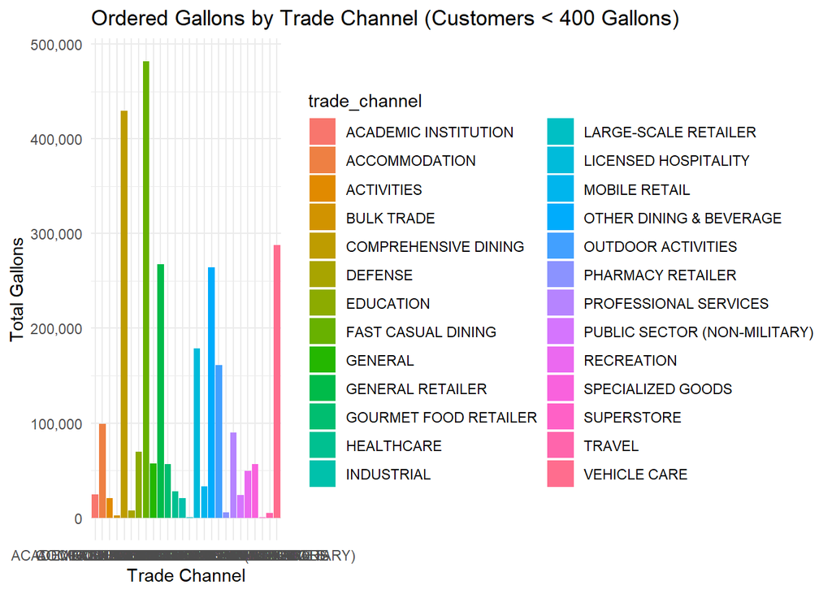

```r
# for customers with < 400 gallons per year
joined_data_with_cost %>%
  group_by(customer_number, trade_channel) %>%
  summarize(total_gallons = sum(ordered_gallons + ordered_cases, na.rm = TRUE)) %>%
  filter(total_gallons < 400) %>%
  group_by(trade_channel) %>%
  summarize(gallons = sum(total_gallons)) %>%
  ggplot(aes(x = trade_channel, y = gallons, fill = trade_channel)) +
  geom_bar(stat = "identity") +
  ggtitle("Ordered Gallons by Trade Channel (Customers < 400 Gallons)") +
  labs(x = "Trade Channel", y = "Total Gallons") +
  scale_y_continuous(labels = scales::comma) +
  theme_minimal()
```

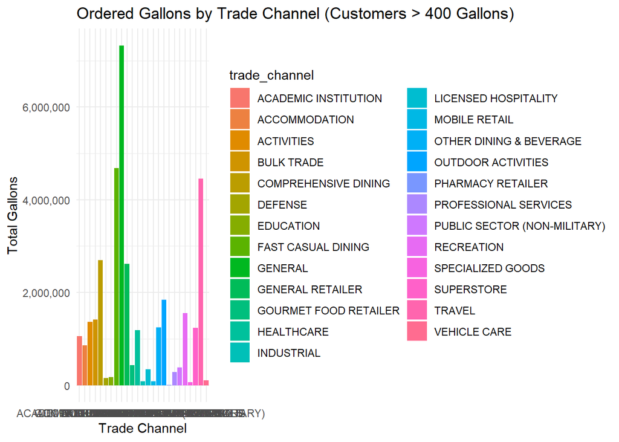

```r
# for customers with > 400 gallons per year
joined_data_with_cost %>%
  group_by(customer_number, trade_channel) %>%
  summarize(total_gallons = sum(ordered_gallons + ordered_cases, na.rm = TRUE)) %>%
  filter(total_gallons > 400) %>%
  group_by(trade_channel) %>%
  summarize(gallons = sum(total_gallons)) %>%
  ggplot(aes(x = trade_channel, y = gallons, fill = trade_channel)) +
  geom_bar(stat = "identity") +
  ggtitle("Ordered Gallons by Trade Channel (Customers > 400 Gallons)") +
  labs(x = "Trade Channel", y = "Total Gallons") +
  scale_y_continuous(labels = scales::comma) +
  theme_minimal()
```